# Clinical Definition

The purpose of this notebook is to create a multiple logistic regression model to predict MDRO status using composite features based on antibiotic resistance. The features used to create the model are shown below.

Dummy variables were created by grouping antibiotics into the following categories:

- Resistant to **Meropenem OR Imipenem**
- Resistant to **Ertapenem**
- Resistant to **Ceftazidime**
- Resistant to **Gentamicin OR Tobramycin**
- Resistant to **Cefepime**
- Resistant to **Pip-Tazo**
- Resistant to **Ceftriaxone**

```r
## load libraries
library(dplyr)
library(ggplot2)
library(reshape2)
library(caret)
library(pROC)
library(gplots)
library(RColorBrewer)
```

## Load Data

Load data from `csv` file

```r
## load data from csv
mdro = read.csv("MDRO expanded isolate June 2015 - Sept 2016-no-definitions.csv", skip=1)

## replace NAs with zero
mdro[is.na(mdro)] = 0

## setup color theme
## create color theme
cols <- brewer.pal(name="PiYG", n=11)
col_high <- cols[1]
col_low <- cols[5]
col_ramp <- colorRampPalette(c(col_low, col_high))
```

## Compute Antibiotic Weights

Antibiotic resitance score is computed as $$R = \sum_{i=1}^{n}x_i w_i$$ where $x_i$ is 0 if organism is sensitive to antibiotic $i$ and 1 if organism is resistant to antibiotic $i$. $n$ is the total number of antibiotics text (18 in this case) and $w_i$ is the weight for antibiotic $i$ and is calculated such that *stronger* antibiotics recieve larger weights and *weaker* antibiotics recieve smaller weights. Antibiotic *strength* is calculated as the fraction of susceptible organism as follows $$w_i = 1 - Q_i$$ where $Q_i$ represents the fraction of organisms resistant to antibiotic $i$.

```r
## compute antibiotic weights
abx_weights = colMeans(1 - do.call(rbind, by(mdro[,3:20], list(mdro$X), colMeans)))

## calcualte antibiotic resistance scores
mdro_scores = as.matrix(mdro[,3:20]) %*% abx_weights
mdro$scores = as.numeric(mdro_scores)
```

### Plot antibiotic weights

This plot shows the weights assigned to each antibiotic based on the fraction of susceptible organisms (the more susceptible organisms the stronger the weight).

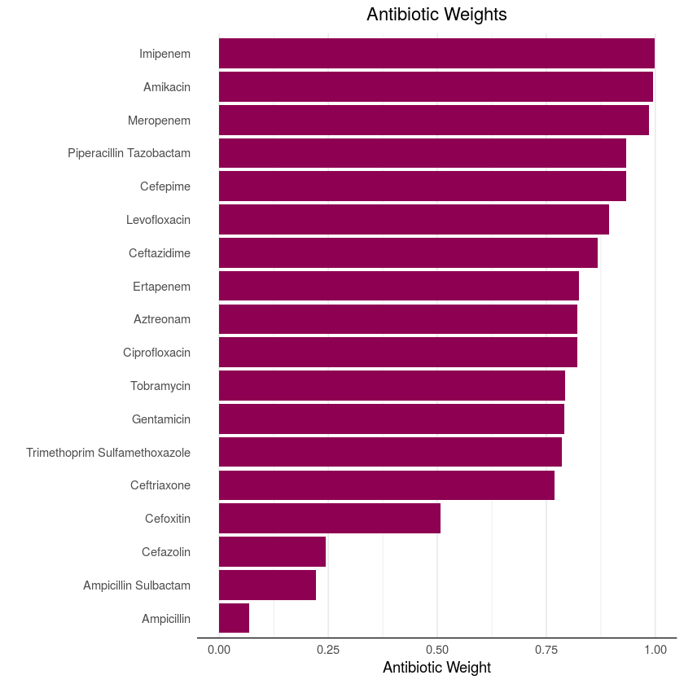

```r
## plot antibiotic weights calculted for each antibiotic
tmp = data.frame(name = names(abx_weights), weight = abx_weights)

abx_weight_plt = ggplot(tmp, aes(x=reorder(gsub('\\.', ' ',name), weight), y=weight)) +
  geom_bar(stat='identity', fill=col_high) +
  theme_minimal() +
  coord_flip() +
  labs(y="Antibiotic Weight", x="", title="Antibiotic Weights") +
  theme(panel.grid.major.y = element_blank(),
        axis.line.x = element_line(),
        plot.title = element_text(hjust=0.5))

abx_weight_plt
ggsave(abx_weight_plt, file='abx-weights.svg')
```

### Show distribution of antibiotic resistance scores for all organisms in dataset

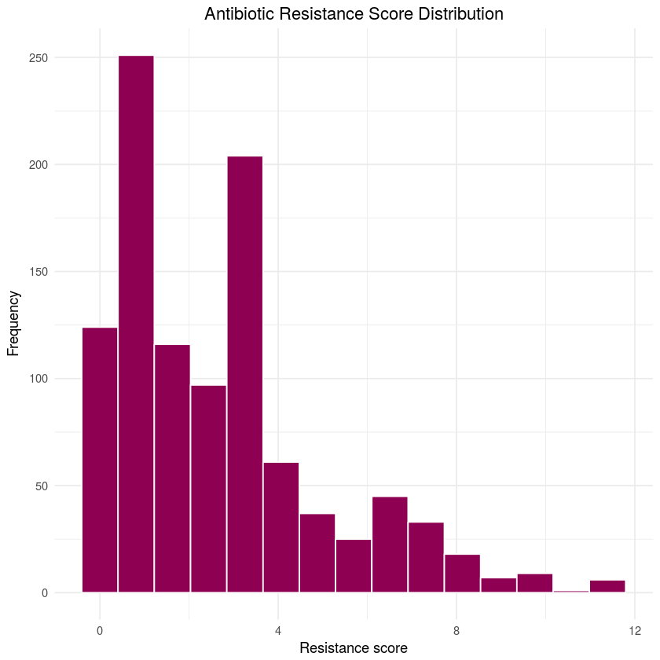

```r
# Plot resistance score distribution for all organisms
tmp = data.frame(scores = mdro_scores)
score_hist = ggplot(tmp, aes(x=scores)) +
  geom_histogram(bins=15, col='white', fill=col_high) +
  theme_minimal() +
  labs(title="Antibiotic Resistance Score Distribution", x="Resistance score", y="Frequency") +
  theme(plot.title = element_text(hjust=0.5))

ggsave(score_hist, file='score-histogram.svg' )
score_hist
```

# Create Composite Features

```r
# Compute composite features
tmp = mdro %>%
  mutate(mdro = as.factor((scores > 5)),
         meropenem_imipenem = as.numeric(Meropenem == 1 | Imipenem == 1),
         ertapenem = as.numeric(Ertapenem == 1),
         ceftazidime = as.numeric(Ceftazidime == 1),
         ceftriaxone = as.numeric(Ceftriaxone == 1),
         gentamicin_tobramycin = as.numeric(Gentamicin == 1 | Tobramycin == 1),
         cefepime = as.numeric(Cefepime == 1),
         piperacillin_tazobactam = as.numeric(Piperacillin.Tazobactam == 1)) %>%
  select(mdro,
         meropenem_imipenem,
         ertapenem,
         ceftazidime,
         ceftriaxone,
         gentamicin_tobramycin,
         cefepime,
         piperacillin_tazobactam)

# Show example of the features
head(tmp)
```

| mdro | meropenem_imipenem | ertapenem | ceftazidime | ceftriaxone | gentamicin_tobramycin | cefepime | piperacillin_tazobactam |
| --- | --- | --- | --- | --- | --- | --- | --- |
| FALSE | 0 | 1 | 0 | 0 | 0 | 1 | 0 |
| FALSE | 0 | 1 | 0 | 0 | 0 | 0 | 0 |
| FALSE | 0 | 1 | 0 | 0 | 0 | 0 | 0 |
| TRUE | 0 | 1 | 1 | 1 | 0 | 0 | 0 |
| FALSE | 0 | 1 | 0 | 0 | 0 | 0 | 0 |
| TRUE | 0 | 1 | 1 | 1 | 0 | 1 | 0 |

## Train MLR Model and Inspect $\beta$ Coefficients

Create a MLR model using 10-fold cross validation. Cross validation used to prevent overfitting

```r
## convert dependent variable to factor
tmp$mdro = factor(tmp$mdro, c('TRUE', 'FALSE'))
```

|  | meropenem_imipenem | ertapenem | ceftazidime | ceftriaxone | gentamicin_tobramycin | cefepime | piperacillin_tazobactam |
| --- | --- | --- | --- | --- | --- | --- | --- |
| meropenem_imipenem | 1.0000000 | 0.25117446 | 0.20175068 | 0.2148589 | 0.11150602 | 0.2695917 | 0.27918424 |
| ertapenem | 0.2511745 | 1.00000000 | 0.02469374 | 0.6827901 | -0.01545247 | 0.1060965 | 0.07597348 |
| ceftazidime | 0.2017507 | 0.02469374 | 1.00000000 | 0.5203661 | 0.23710124 | 0.7241674 | 0.43674965 |
| ceftriaxone | 0.2148589 | 0.68279008 | 0.52036606 | 1.0000000 | 0.12837326 | 0.4498153 | 0.19342267 |
| gentamicin_tobramycin | 0.1115060 | -0.01545247 | 0.23710124 | 0.1283733 | 1.00000000 | 0.2797925 | 0.09222594 |
| cefepime | 0.2695917 | 0.10609648 | 0.72416745 | 0.4498153 | 0.27979251 | 1.0000000 | 0.35822056 |
| piperacillin_tazobactam | 0.2791842 | 0.07597348 | 0.43674965 | 0.1934227 | 0.09222594 | 0.3582206 | 1.00000000 |

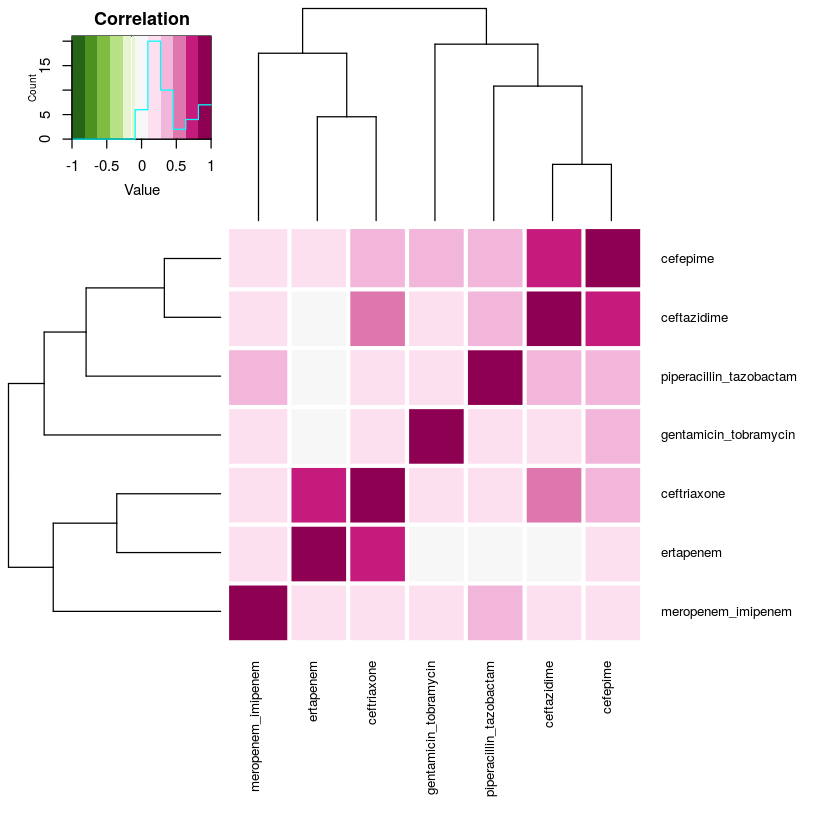

```r
## check for correlation among features
cor_mat = cor(tmp[,2:8])
## show correaltion values
cor_mat
## plot correlation heatmap
heatmap.2(cor_mat,
          col=rev(brewer.pal(name='PiYG',n=11)),
          margins = c(10,10),
          key.title='Correlation',
          cexRow=0.8,
          cexCol=0.8,
          colsep=1:ncol(cor_mat),
          rowsep=1:nrow(cor_mat),
          trace='none')
```

Looks like there is some correlation between ceftazidime and cefepime, as well as ertapenem and ceftriaxone. Not sure whether we should drop any of these from the model.

### Create fully specified model (all features)

First I create a fully specified multiple logistic regression model using all composite features created above (including those that are correlated e.g. cefepime and ceftazidime)

```r
## build fuly specified model
full_model <- train(mdro ~ .,
                             data = tmp,
                             method = 'glm',
                             trControl = trainControl(method = 'repeatedcv', repeats=10))

## show beta estimates
summary(full_model)

## show model performance
predicted_vals = predict(full_model, tmp)
true_vals = tmp$mdro
confusionMatrix(table(predicted_vals, true_vals))
```

```
Call:
NULL

Deviance Residuals:
     Min        1Q    Median        3Q       Max
-2.48244   0.00001   0.00001   0.06441   3.06256

Coefficients:
                         Estimate Std. Error z value Pr(>|z|)
(Intercept)               23.8851  1018.2861   0.023  0.98129
meropenem_imipenem        -3.0767     0.6810  -4.518 6.24e-06 ***
ertapenem                 -3.1428     0.6690  -4.698 2.63e-06 ***
ceftazidime               -3.3266     0.6796  -4.895 9.82e-07 ***
ceftriaxone              -17.7080  1018.2862  -0.017  0.98613
gentamicin_tobramycin     -4.7118     0.6324  -7.450 9.32e-14 ***
cefepime                  -3.0028     0.4528  -6.631 3.33e-11 ***
piperacillin_tazobactam   -1.4579     0.5435  -2.682  0.00731 **
---
Signif. codes:  0 ‘***’ 0.001 ‘**’ 0.01 ‘*’ 0.05 ‘.’ 0.1 ‘ ’ 1

(Dispersion parameter for binomial family taken to be 1)

    Null deviance: 924.21  on 1033  degrees of freedom
Residual deviance: 225.96  on 1026  degrees of freedom
AIC: 241.96

Number of Fisher Scoring iterations: 20
```

```
Confusion Matrix and Statistics

              true_vals
predicted_vals TRUE FALSE
         TRUE   153    29
         FALSE   17   835

               Accuracy : 0.9555
                 95% CI : (0.9411, 0.9672)
    No Information Rate : 0.8356
    P-Value [Acc > NIR] : <2e-16

                  Kappa : 0.8425
 Mcnemar's Test P-Value : 0.1048

            Sensitivity : 0.9000
            Specificity : 0.9664
         Pos Pred Value : 0.8407
         Neg Pred Value : 0.9800
             Prevalence : 0.1644
         Detection Rate : 0.1480
   Detection Prevalence : 0.1760
      Balanced Accuracy : 0.9332

       'Positive' Class : TRUE
```

Ceftriaxone is not significant in the fully specified model model results are as follows

| Sensitivity | 0.90 |
| --- | --- |
| Specificity | 0.97 |
| Accuracy | 0.96 |
| $\kappa$ | 0.84 |

### Drop ceftriaxone from model

```r
## create first nested model by dropping ceftriaxone
nested_1 <- train(mdro ~ .-ceftriaxone,
             data = tmp,
             method = "glm",
             trControl =trainControl(method = 'repeatedcv', repeats=10))

## show beta estiamtes
summary(nested_1)

## calculate model performance
pred_vals = predict(nested_1, tmp)
true_vals = tmp$mdro

confusionMatrix(table(pred_vals, true_vals))
```

```
Call:
NULL

Deviance Residuals:
     Min        1Q    Median        3Q       Max
-2.56027   0.03034   0.03034   0.27732   3.01998

Coefficients:
                        Estimate Std. Error z value Pr(>|z|)
(Intercept)               7.6837     0.6915  11.111  < 2e-16 ***
meropenem_imipenem       -3.0962     0.6688  -4.629 3.67e-06 ***
ertapenem                -4.4447     0.6088  -7.301 2.85e-13 ***
ceftazidime              -4.5683     0.6530  -6.996 2.63e-12 ***
gentamicin_tobramycin    -4.4125     0.5470  -8.066 7.26e-16 ***
cefepime                 -3.2204     0.4568  -7.049 1.80e-12 ***
piperacillin_tazobactam  -1.3020     0.5477  -2.377   0.0175 *
---
Signif. codes:  0 ‘***’ 0.001 ‘**’ 0.01 ‘*’ 0.05 ‘.’ 0.1 ‘ ’ 1

(Dispersion parameter for binomial family taken to be 1)

    Null deviance: 924.21  on 1033  degrees of freedom
Residual deviance: 239.38  on 1027  degrees of freedom
AIC: 253.38

Number of Fisher Scoring iterations: 8
```

```
Confusion Matrix and Statistics

         true_vals
pred_vals TRUE FALSE
    TRUE   148    24
    FALSE   22   840

               Accuracy : 0.9555
                 95% CI : (0.9411, 0.9672)
    No Information Rate : 0.8356
    P-Value [Acc > NIR] : <2e-16

                  Kappa : 0.8388
 Mcnemar's Test P-Value : 0.8828

            Sensitivity : 0.8706
            Specificity : 0.9722
         Pos Pred Value : 0.8605
         Neg Pred Value : 0.9745
             Prevalence : 0.1644
         Detection Rate : 0.1431
   Detection Prevalence : 0.1663
      Balanced Accuracy : 0.9214

       'Positive' Class : TRUE
```

After dropping ceftriaxone (because it was not significant in fully specified model) we get the following performance

| Sensitivity | 0.87 |
| --- | --- |
| Specificity | 0.97 |
| Accuracy | 0.96 |
| $\kappa$ | 0.84 |

## Using $\beta$ estimates from MLR to create clinical definition

I use the $\beta$ estimates from the model created after dropping ceftriaxone. A point system was created created by taking the aboslute value of the $\beta$ estiamtes and rounding to the nearest whole number. We can now calcualte a clinical score for each organism by summing the total number of points depending on whether the organism is resistant or susceptible for each antibotic or group of antibiotics. For example, suppose an organism is resistant to cefepime and gentamycin, we would calculate the clinical score as follows $$score = 4 + 3 = 7$$. This score exceeds the threshold of 6 and therefore we would classify it as an MDRO. The treshold we use here (6) is loosly derived from the intercept of the MLR model, however due to rounding of the $\beta$ coefficients it is not exactly the same as the intercept and was selected based on the ROC analysis below. Basically, the threshold of 6 was selected as it provides a good balance between sensitivity and specificity. Later, I test the performance of our model using various possible threshold in the ROC analysis.

| Drug | Points |
| --- | --- |
| Pip/Tazo | +1 |
| Meropenem/Imipenem | +3 |
| Cefepime | +3 |
| Ertapenem | +4 |
| Ceftazidime | +5 |
| Gent/Tobra | +4 |
| MDRO Threshold | > 6 |

### Applying the clinical definition

In this section I create a function that direcly implements the clinical definition (i.e. uses the point system above) to calculate clinical scores based on organisms resistance pattern. This function allows you to set the weights (we use the ones derived/specified in the previous table as defaults) and a threshold (we use 6 as the default). We can then calculate a clinical score by passing an example resistance pattern to the function

```r
# Function used to create predictions based on clinical definition
clinical_prediction <- function(data, weights = c(1, 3, 3, 4, 5, 4), thresh=6){
    score = as.matrix(subset(data, select = c(piperacillin_tazobactam,
                                      meropenem_imipenem,
                                      cefepime,
                                      ertapenem,
                                      ceftazidime,
                                      gentamicin_tobramycin))) %*% weights
    res = data.frame(score = score, class = (score > thresh))
    res$class = factor(res$class, levels = c('TRUE', 'FALSE'))
    res
}
```

```r
## test the clinical_prediction function using an example organism

## select a random organisms from the dataset
message("First example organism resistance pattern...")
example_organism1 = tmp[3,]
## show resistance pattern
example_organism1
## apply clinical definition to example organism
message("Our prediction based on clinical definition!")
clinical_prediction(example_organism1)

## try another organism
message("Second example organism resistance pattern...")
example_organism2 = tmp[1,]
example_organism2
message("Our prediction based on clinical definition")
clinical_prediction(example_organism2)
```

```
First example organism resistance pattern...
```

|  | mdro | meropenem_imipenem | ertapenem | ceftazidime | ceftriaxone | gentamicin_tobramycin | cefepime | piperacillin_tazobactam |
| --- | --- | --- | --- | --- | --- | --- | --- | --- |
| 3 | FALSE | 0 | 1 | 0 | 0 | 0 | 0 | 0 |

```
Our prediction based on clinical definition!
```

|  | score | class |
| --- | --- | --- |
| 3 | 4 | FALSE |

```
Second example organism resistance pattern...
```

| mdro | meropenem_imipenem | ertapenem | ceftazidime | ceftriaxone | gentamicin_tobramycin | cefepime | piperacillin_tazobactam |
| --- | --- | --- | --- | --- | --- | --- | --- |
| FALSE | 0 | 1 | 0 | 0 | 0 | 1 | 0 |

```
Our prediction based on clinical definition
```

| score | class |
| --- | --- |
| 7 | TRUE |

### Interpretation

The first example organism has a simple resistance pattern (only resistant to ertapenem) and while it achieves a clinical score of 4, it does not exceed the treshold of 6 and is therefore classified as FALSE (meaning it's not MDRO) according to our clinical definition.

The second example organisms has a slightly more complex resistance pattern (resistant to cefepime and ertapenem) and recieves a score of 7 which exceeds our threshold of 6, and is thus classified as TRUE (meaning MDRO)

# ROC Analysis

ROC curves will be used to compare the MLR definition against the Clinical Definition

```r
## create ROC data using MLR model with ceftriaxone dropped
mlr_preds = predict(nested_1, tmp, type = 'prob')[,1]
mlr_roc <- roc(as.numeric(tmp$mdro), mlr_preds, direction = ">")
message("AUC for MLR model after dropping ceftriaxone")
mlr_roc_dat = data.frame(sens = mlr_roc$sensitivities,
                         spec=mlr_roc$specificities,
                         thresh = mlr_roc$thresholds,
                         model = "MLR")
mlr_roc

## create ROC data using the clinical definition
clinical_preds = clinical_prediction(tmp)[,1]
clinical_roc <- roc(tmp$mdro, clinical_preds, thresholds = seq(0,20,by=0.5), direction=">")
message("AUC for clinical definition")
clinical_roc_dat = data.frame(sens = clinical_roc$sensitivities,
                              spec = clinical_roc$specificities,
                              thresh = clinical_roc$thresholds,
                              model = "Clinical")
clinical_roc

## create single dataframe combining sensitivity/specificties/thresholds from mlr and clinical definition
roc_dat = rbind(mlr_roc_dat, clinical_roc_dat)
```

```
AUC for MLR model after dropping ceftriaxone
```

```
Call:
roc.default(response = as.numeric(tmp$mdro), predictor = mlr_preds,     direction = ">")

Data: mlr_preds in 170 controls (as.numeric(tmp$mdro) 1) > 864 cases (as.numeric(tmp$mdro) 2).
Area under the curve: 0.9833
```

```
AUC for clinical definition
```

```
Call:
roc.default(response = tmp$mdro, predictor = clinical_preds,     direction = ">", thresholds = seq(0, 20, by = 0.5))

Data: clinical_preds in 170 controls (tmp$mdro TRUE) > 864 cases (tmp$mdro FALSE).
Area under the curve: 0.9813
```

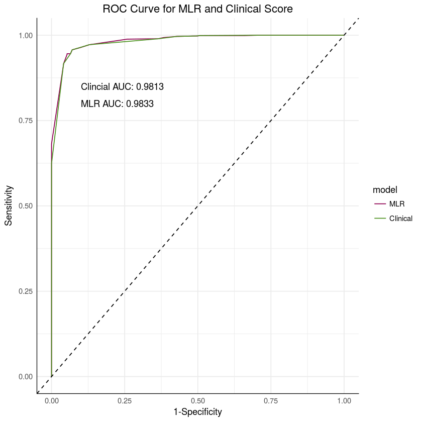

```r
## plot ROC curves for MLR and clinical definition
ggplot(roc_dat[order(roc_dat$sens),], aes(x=1-spec, y=sens)) +
  geom_line(aes(col=model)) +
  scale_color_manual(values=c(cols[1], cols[10])) +
  annotate("text", x=c(0.1, 0.1), y=c(0.80, 0.85), label=c("MLR AUC: 0.9833", "Clincial AUC: 0.9813"), hjust=0) +
  geom_abline(lty=2) +
  theme_minimal() +
  ylim(c(0,1)) +
  labs(title="ROC Curve for MLR and Clinical Score", x="1-Specificity", y="Sensitivity") +
  theme(axis.line.x = element_line(),
        axis.line.y = element_line(),
        plot.title = element_text(hjust=0.5))
```

# Compare Clinical Predictions vs Regression Predictions

```r
## create predictions from our clinical scoreing system
clinical_preds = clinical_prediction(tmp, thresh=6)$class
## create predictions from our nested_1 model (model where we dropped ceftriaxone)
regression_preds = predict(nested_1, tmp)
```

```r
## look at some stats comparing the two methods
confusionMatrix(clinical_preds, tmp$mdro)
```

```
Confusion Matrix and Statistics

          Reference
Prediction TRUE FALSE
     TRUE   158    37
     FALSE   12   827

               Accuracy : 0.9526
                 95% CI : (0.9378, 0.9647)
    No Information Rate : 0.8356
    P-Value [Acc > NIR] : < 2.2e-16

                  Kappa : 0.8371
 Mcnemar's Test P-Value : 0.0006068

            Sensitivity : 0.9294
            Specificity : 0.9572
         Pos Pred Value : 0.8103
         Neg Pred Value : 0.9857
             Prevalence : 0.1644
         Detection Rate : 0.1528
   Detection Prevalence : 0.1886
      Balanced Accuracy : 0.9433

       'Positive' Class : TRUE
```

### What's a good cutoff for our clinical definition?

To find a good cutoff we need to test all possible cutoffs to find one that provides good balance between sensitivity and specificity...since our clinical scoring system only provides interger scores we only need to check integer cutoffs

```r
## use this package to calculate cohen's kappa
library(psych)
```

```r
## dataframe for storing sensitivity, specificity, kappa, and threshold/cutoff values
cmstats = data.frame(sens=NA, spec=NA, kappa=NA, thresh=NA)

## loop over all possible cutoffs
for(i in 1:20){
    cm = table(clinical_prediction(tmp, thresh=i)$class, tmp$mdro)
    cmstats[i,1] = sensitivity(cm)
    cmstats[i,2] = specificity(cm)
    cmstats[i,3] = cohen.kappa(cm)$kappa
    cmstats[i,4] = i
}

## show sensitivity/specificity and thresholds
cmstats
```

| sens | spec | kappa | thresh |
| --- | --- | --- | --- |
| 1.00000000 | 0.6226852 | 0.35176652 | 1 |
| 1.00000000 | 0.6226852 | 0.35176652 | 2 |
| 1.00000000 | 0.6238426 | 0.35289134 | 3 |
| 0.95882353 | 0.9166667 | 0.75894591 | 4 |
| 0.93529412 | 0.9456019 | 0.81184901 | 5 |
| 0.92941176 | 0.9571759 | 0.83714442 | 6 |
| 0.87058824 | 0.9722222 | 0.83884695 | 7 |
| 0.63529412 | 0.9895833 | 0.71431796 | 8 |
| 0.57058824 | 0.9965278 | 0.67948446 | 9 |
| 0.50588235 | 0.9976852 | 0.62455880 | 10 |
| 0.49411765 | 0.9988426 | 0.61682498 | 11 |
| 0.29411765 | 1.0000000 | 0.41049031 | 12 |
| 0.16470588 | 1.0000000 | 0.24785362 | 13 |
| 0.16470588 | 1.0000000 | 0.24785362 | 14 |
| 0.14705882 | 1.0000000 | 0.22368353 | 15 |
| 0.05294118 | 1.0000000 | 0.08543834 | 16 |
| 0.03529412 | 1.0000000 | 0.05761793 | 17 |
| 0.03529412 | 1.0000000 | 0.05761793 | 18 |
| 0.02941176 | 1.0000000 | 0.04820084 | 19 |
| 0.00000000 | 1.0000000 | 0.00000000 | 20 |

From the output above we can see that a cutoff of 6 gives good sensitivity and specificity (0.93, 0.96)...this seems like a good value but I guess it depends if we value sensitivity over specificity...for example we can gain a little specificity by increasing the threshold to 7, however we loose sensitivity (0.87).

# Validate Definition using Ceftriaxone

We would expect most of the MDROs to be resistant to ceftriaxone. Turns out that when using the clinical score to identify MDRO's, 98.97% of them are resistant to ceftriaxone and 42.79% of all ceftriaxone resistant bugs are considered MDRO by the definition

```r
## show frequency of ceftriaxone resistant bugs within MDRO/Non-MDRO classes
MDRO = clinical_preds
table(MDRO, mdro$Ceftriaxone)
```

```
MDRO      0   1
  TRUE    2 193
  FALSE 581 258
```

In the table above we can see that 193/195 MDRO's are resistant to ceftriaxone

# Plot Definitions

Here I plot each of the organisms as well as their MDRO designation (mapped to color) based on whether or not our clinical score classified it as MDRO/Non-MDRO...additionally, I plot a vertical line at x=5 to show the original antibiotic resistance score cutoff we used to train our model, this let's us look at how our clinical score compares to the original threshold of antibiotic score > 5.

```r
mdro$clinical_def = clinical_preds
mdro$regression_def = regression_preds
mdro$thresh_5_def = (mdro$scores > 5)
```

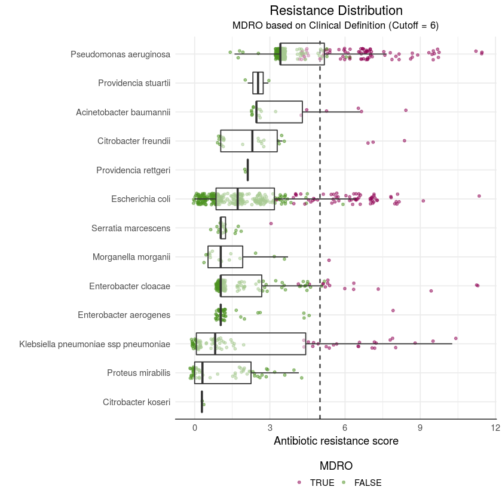

```r
## create plot comparing clinical score classification against antibiotic resistance score > 5 classification
clinical_def <- ggplot(mdro, aes(x=reorder(X, scores, median), y=scores)) +
  geom_hline(yintercept = 5, lty=2) +
  geom_point(aes(col=clinical_def),
             position = position_jitter(width = 0.2, height = 0.2),
             size=1, alpha=0.5) +
  geom_boxplot(outlier.colour = NA, alpha=0.5) +
  theme_minimal() +
  scale_color_manual(values = c(cols[1], cols[10]), guide = guide_legend(title="MDRO",
                                                                         title.position='top',
                                                                         title.hjust=0.5)) +
  labs(title="Resistance Distribution",
       subtitle="MDRO based on Clinical Definition (Cutoff = 6)",
       x="",
       y="Antibiotic resistance score") +
  coord_flip() +
  theme(plot.title = element_text(hjust=0.5),
        plot.subtitle = element_text(hjust=0.5),
        axis.line.x = element_line(),
        legend.position = 'bottom')
clinical_def
ggsave(clinical_def, file='clinical-definition-resistance-distribution.png')
```

## Visually Compare all Three Definitions (MLR, Clinical, Threshold > 5)

```r
# Create long-dataframe
tmp_defs = mdro %>%
    select(scores, clinical_def, regression_def, thresh_5_def) %>%
    melt(id.vars = 'scores')
```

```r
tmp_defs$value = factor(tmp_defs$value, c(TRUE, FALSE))
```

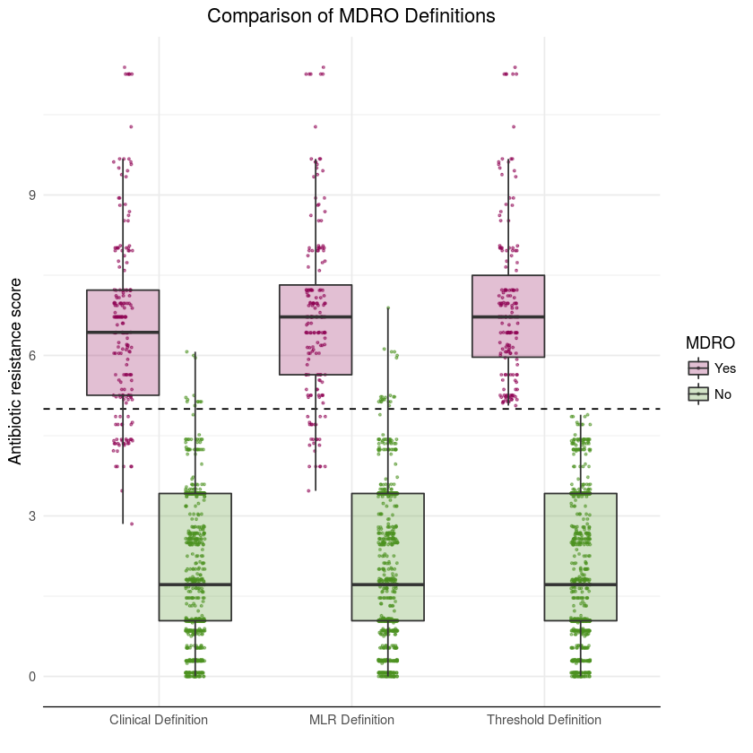

```r
# plot comparing clinical score method vs. MLR method vs. original threshold (resistance score > 5) classifications
def_comp_plt <- ggplot(tmp_defs, aes(x=variable, y=scores, fill = value)) +
  geom_hline(yintercept = 5, lty=2) +
  geom_point(position = position_jitterdodge(jitter.width = 0.2),
             aes(col=value), size=0.5, alpha=0.5) +
  geom_boxplot(alpha=0.25, outlier.colour = NA) +
  scale_fill_manual(values = c(cols[1], cols[10]), name='MDRO', labels=c('Yes', 'No')) +
  scale_color_manual(values = c(cols[1], cols[10]), guide='none') +
  #scale_fill_brewer(palette = 'Set1', name='MDRO', labels=c('Yes', 'No')) +
  #scale_color_brewer(palette = 'Set1', guide='none') +
  scale_x_discrete(labels = c('Clinical Definition', 'MLR Definition', 'Threshold Definition')) +
  labs(title='Comparison of MDRO Definitions', x='', y='Antibiotic resistance score') +
  theme_minimal() +
  theme(axis.line.x = element_line(),
        plot.title = element_text(hjust=0.5))

def_comp_plt
ggsave(def_comp_plt, file='definition-comparisons.png')
```

This plot shows how well our clinical definition approximates the MLR model we built which in turn, approximates the threshold we used to discretize our organisms in the beginning (i.e. we chose to classify any organism with antibiotic resistance score > 5 as MDRO...we then trained a MLR model to estimate $\beta$ coefficients using this treshold...we then created our clinical definition based on those $\beta$ estiamtes.)